# Milestone Report - Capstone Project

Stephen Ewing

July 21, 2018

## Loading the data

Here’s the code to check if the zip file for the project is in the working directory and download it if it isn’t. It will then unzip it if it hasn’t already been unzipped.

```r
filename <- "Coursera-SwiftKey.zip"
if(!file.exists(filename)){
        fileURL <- "https://d396qusza40orc.cloudfront.net/dsscapstone/dataset/Coursera-SwiftKey.zip"
        download.file(fileURL, filename)
}
if(!dir.exists("/final/en_US/")){
        unzip(filename)
}
```

## Preliminary Analysis

First we’ll just look at how long each of the data sets are and some summary stats for the number of characters in the strings.

```r
explore <- data.frame(row.names = c("Number of Strings", "Longest String", "Shortest String", "Average String", "Median String", "File Size (mb)"))

con <- file("./final/en_US/en_US.blogs.txt", "r")
tmp <- readLines(con)
explore$blogs <- c(length(tmp), max(nchar(tmp)), min(nchar(tmp)), round(mean(nchar(tmp)),0), median(nchar(tmp)), round(file.info("./final/en_US/en_US.blogs.txt")$size / 1024 ^ 2, 0))
close(con)

con <- file("./final/en_US/en_US.news.txt", "r")
tmp <- readLines(con)
explore$news <- c(length(tmp), max(nchar(tmp)), min(nchar(tmp)), round(mean(nchar(tmp)),0), median(nchar(tmp)), round(file.info("./final/en_US/en_US.news.txt")$size / 1024 ^ 2, 0))
close(con)

con <- file("./final/en_US/en_US.twitter.txt", "r")
tmp <- readLines(con)
explore$twitter <- c(length(tmp), max(nchar(tmp)), min(nchar(tmp)), round(mean(nchar(tmp)),0), median(nchar(tmp)), round(file.info("./final/en_US/en_US.twitter.txt")$size / 1024 ^ 2, 0))
close(con)
rm(tmp)

explore
```

```
                   blogs  news twitter
Number of Strings 899288 77259 2360148
Longest String     40835  5760     213
Shortest String        1     2       2
Average String       232   203      69
Median String        157   186      64
File Size (mb)       200   196     159
```

There are many more strings in the twitter data set but the strings are much shorter on average. 550mb of text is a huge data set.

## Data Subsetting

Since we don’t need all of the data I’ll sample 10% of it using the `LaF` package and move them to a new sub-directory.

```r
library(NLP)
library(tm)
library(LaF)
```

```r
set.seed(33)
if(!dir.exists("./sample")){
        dir.create("./sample")
}

writeLines(sample_lines("./final/en_US/en_US.blogs.txt", determine_nlines("./final/en_US/en_US.blogs.txt")*0.1, determine_nlines("./final/en_US/en_US.blogs.txt")), "blogsSample.txt")
file.rename(from="./blogsSample.txt", to="./sample/blogsSample.txt")

writeLines(sample_lines("./final/en_US/en_US.news.txt", determine_nlines("./final/en_US/en_US.news.txt")*0.1, determine_nlines("./final/en_US/en_US.news.txt")), "newsSample.txt")
file.rename(from="./newsSample.txt", to="./sample/newsSample.txt")

writeLines(sample_lines("./final/en_US/en_US.twitter.txt", determine_nlines("./final/en_US/en_US.twitter.txt")*0.1, determine_nlines("./final/en_US/en_US.twitter.txt")), "twitterSample.txt")
file.rename(from="./twitterSample.txt", to="./sample/twitterSample.txt")
```

## Preprocessing

Now that we have our sample we can load it into a corpus and start using the `tm` package to clean it up.

```r
filename <- "badwords.txt"
if(!file.exists(filename)){
        fileURL <- "https://storage.googleapis.com/google-code-archive-downloads/v2/code.google.com/badwordslist/badwords.txt"
        download.file(fileURL, filename)
}
badwords <- read.csv("badwords.txt")
badwords <- as.character(badwords[,1])
badwords <- gsub('[])(;:#%$^*\\~{}[&+=@/"`|<>_]+', "", badwords)
```

```r
corp <- Corpus(DirSource("./sample"))
corp <- tm_map(corp, content_transformer(function(x){return(iconv(x, from = "UTF-8", to = "ASCII", sub = ""))}))
corp <- tm_map(corp, content_transformer(tolower))
corp <- tm_map(corp, removeWords, badwords)
corp <- tm_map(corp, removePunctuation)
corp <- tm_map(corp, stripWhitespace)
corp <- tm_map(corp, removeNumbers)
corp <- tm_map(corp, removeWords, stopwords("SMART"))
```

## Exploratory Analysis

Now that we have a clean corpus we can start digging into it to see what we see. I’ll create a Term Document Matrix using the `tm` package.

```r
tdm <- removeSparseTerms(TermDocumentMatrix(corp), 0.999)
```

Load some visualization packages

```r
library(RColorBrewer)
library(ggplot2)
library(wordcloud)
```

Change the tdm into a matrix object, sort it by the word frequency after summing up the word across the 3 sources and store it as a data frame.

```r
m <- as.matrix(tdm)
v <- sort(rowSums(m),decreasing=TRUE)
d1 <- data.frame(word = names(v),freq=v)
save(d1, file="d1.RData")
```

Now we can make a word cloud to visualize the top 100 words.

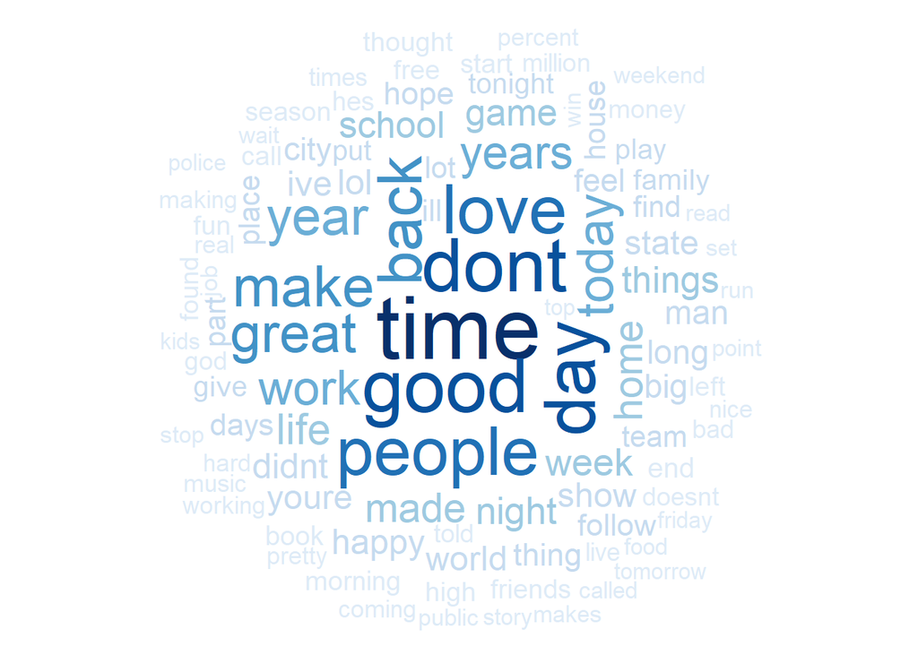

```r
wordcloud(words = d1$word, freq = d1$freq, scale = c(4, 0.5), random.order = FALSE, colors = brewer.pal(9, "Blues"), max.words = 100)
```

Lets take the top 30 words and plot them as a bar chart to better show their relative frequency.

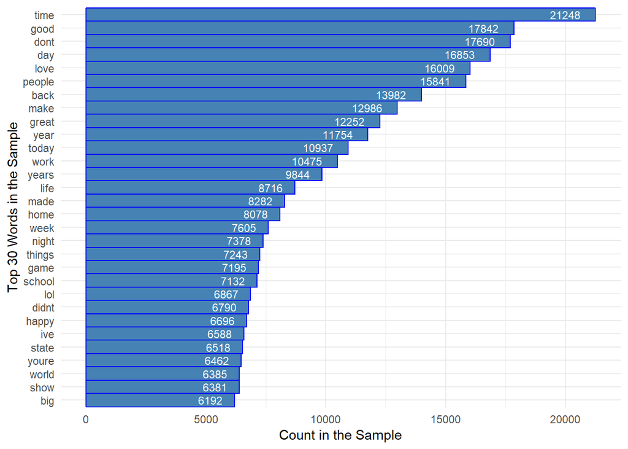

```r
top30 <- d1[1:30,]
top30$word <- factor(top30$word, levels = top30$word[order(top30$freq)])
p <- ggplot(data=top30, aes(y=freq, x=word), ylab="Frequency")
p <- p + geom_bar(stat="identity", width=1, fill="steelblue", color="blue")
p <- p + geom_text(aes(label=freq), color="white", hjust=1.5, size=3)
p <- p + theme_minimal()
p <- p + labs(y="Count in the Sample", x="Top 30 Words in the Sample")
p <- p + coord_flip()
p
```

## Tokenization

The `RWeka` package adds the ability to tokenize a corpus into n-grams. I’ll build Term Document Matrices for digrams through quadgrams.

```r
library(RWeka)
diTok <- function(x) NGramTokenizer(x, Weka_control(min = 2, max = 2))
diTdm <- TermDocumentMatrix(corp, control = list(tokenize = diTok, bounds = list(global = c(3, Inf))))

triTok <- function(x) NGramTokenizer(x, Weka_control(min = 3, max = 3))
triTdm <- TermDocumentMatrix(corp, control = list(tokenize = triTok, bounds = list(global = c(3, Inf))))

quadTok <- function(x) NGramTokenizer(x, Weka_control(min = 4, max = 4))
quadTdm <- TermDocumentMatrix(corp, control = list(tokenize = quadTok, bounds = list(global = c(2, Inf))))
```

Now we can do the same matrix conversion we did for the single words to make a frequency list for each of the others and save them so we can use them later.

```r
m2 <- as.matrix(diTdm)
v2 <- sort(rowSums(m2),decreasing=TRUE)
d2 <- data.frame(word = names(v2),freq=v2)

m3 <- as.matrix(triTdm)
v3 <- sort(rowSums(m3),decreasing=TRUE)
d3 <- data.frame(word = names(v3),freq=v3)

m4 <- as.matrix(quadTdm)
v4 <- sort(rowSums(m4),decreasing=TRUE)
d4 <- data.frame(word = names(v4),freq=v4)
```

```r
library(stringr)
d2$c1 <- word(d2$word, 1)
d2$c2 <- word(d2$word, -1)
save(d2, file="d2.RData")

d3$c1 <- word(d3$word, 1, 2)
d3$c2 <- word(d3$word, -1)
save(d3, file="d3.RData")

d4$c1 <- word(d4$word, 1, 3)
d4$c2 <- word(d4$word, -1)
save(d4, file="d4.RData")
```

Now we can make a word cloud to visualize the top digrams.

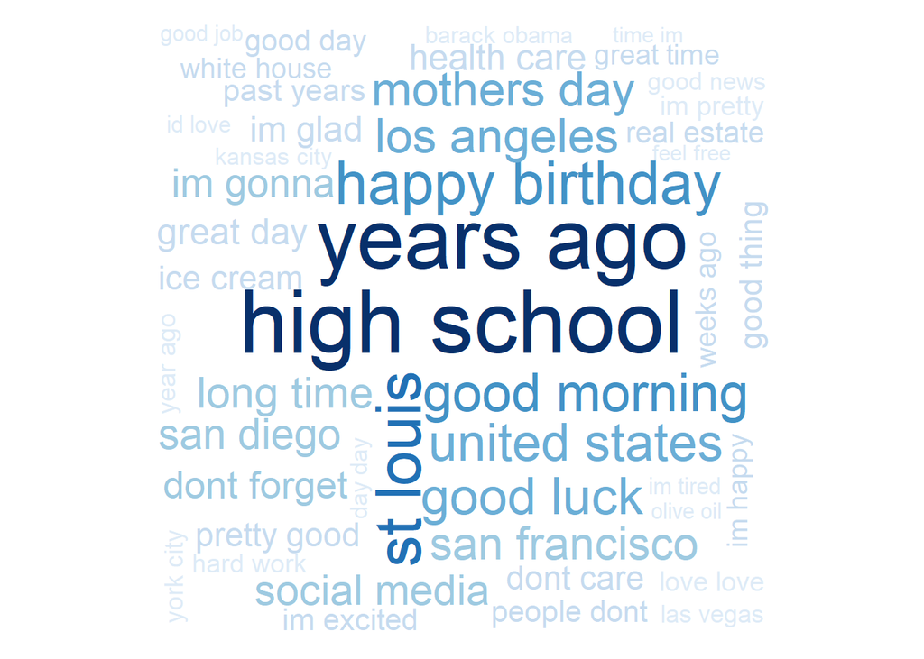

```r
wordcloud(words = d2$word, freq = d2$freq, scale = c(4, 0.5), random.order = FALSE, colors = brewer.pal(9, "Blues"), max.words = 100)
```

And the top trigrams.

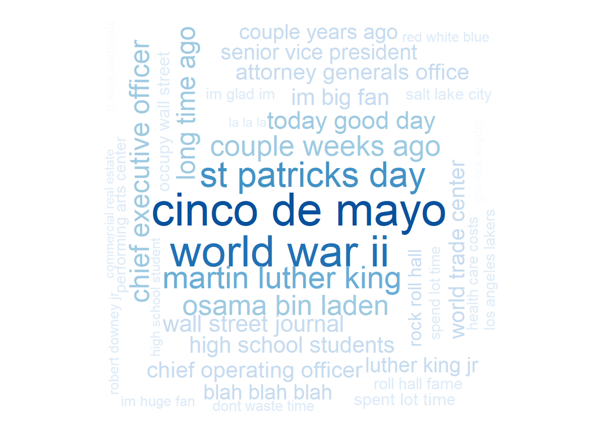

```r
wordcloud(words = d3$word, freq = d3$freq, scale = c(4, 0.5), random.order = FALSE, colors = brewer.pal(9, "Blues"), max.words = 100)
```

And the top quadgrams.

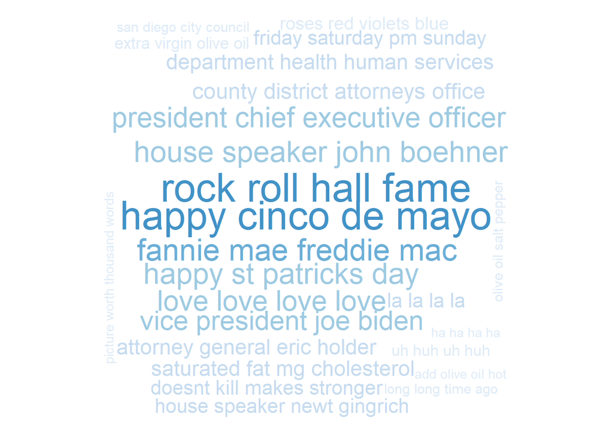

```r
wordcloud(words = d4$word, freq = d4$freq, scale = c(4, 0.5), random.order = FALSE, colors = brewer.pal(9, "Blues"), max.words = 100)
```

Relative frequency of the top 30 digrams

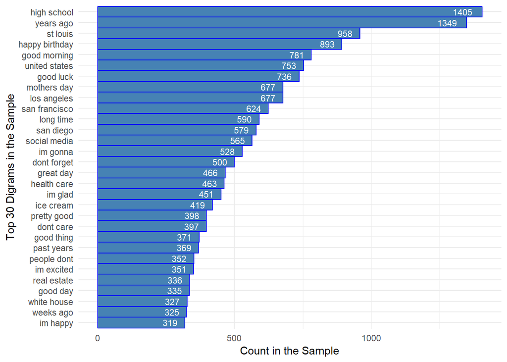

```r
top30 <- d2[1:30,]
top30$word <- factor(top30$word, levels = top30$word[order(top30$freq)])
p <- ggplot(data=top30, aes(y=freq, x=word), ylab="Frequency")
p <- p + geom_bar(stat="identity", width=1, fill="steelblue", color="blue")
p <- p + geom_text(aes(label=freq), color="white", hjust=1.5, size=3)
p <- p + theme_minimal()
p <- p + labs(y="Count in the Sample", x="Top 30 Digrams in the Sample")
p <- p + coord_flip()
p
```

Relative frequency of the top 30 trigrams

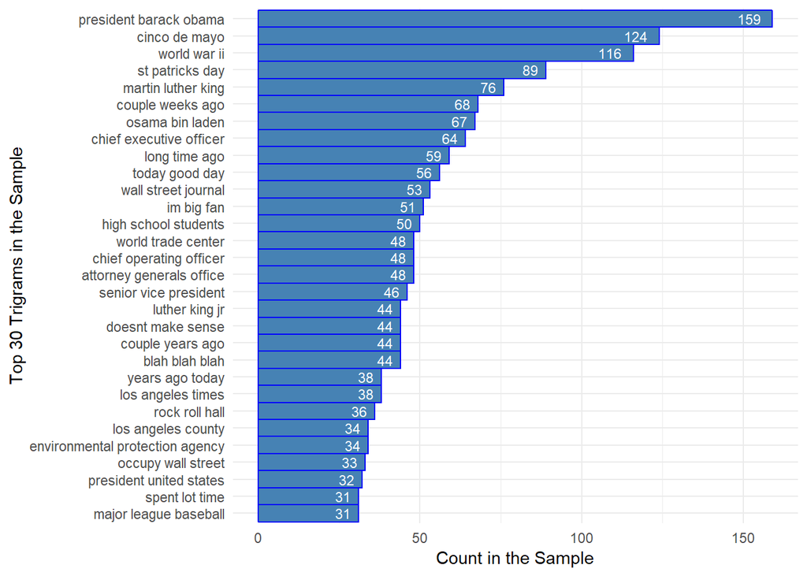

```r
top30 <- d3[1:30,]
top30$word <- factor(top30$word, levels = top30$word[order(top30$freq)])
p <- ggplot(data=top30, aes(y=freq, x=word), ylab="Frequency")
p <- p + geom_bar(stat="identity", width=1, fill="steelblue", color="blue")
p <- p + geom_text(aes(label=freq), color="white", hjust=1.5, size=3)
p <- p + theme_minimal()
p <- p + labs(y="Count in the Sample", x="Top 30 Trigrams in the Sample")
p <- p + coord_flip()
p
```

Relative frequency of the top 30 quadgrams

[figure not shown]

```r
top30 <- d4[1:30,]
top30$word <- factor(top30$word, levels = top30$word[order(top30$freq)])
p <- ggplot(data=top30, aes(y=freq, x=word), ylab="Frequency")
p <- p + geom_bar(stat="identity", width=1, fill="steelblue", color="blue")
p <- p + geom_text(aes(label=freq), color="white", hjust=1.5, size=3)
p <- p + theme_minimal()
p <- p + labs(y="Count in the Sample", x="Top 30 Trigrams in the Sample")
p <- p + coord_flip()
p
```